# Modelo Lineal Generalizado para la prediccion de cancer de mama

Alvaro Perona

2024-02-27

Cargamos las librerias que vamos a usar en el script

```r
library(tidyverse)
library(ggplot2)
library(dplyr)
library(stringr)
library(MASS)
library(pROC)
```

Cargamos los datos con los que vamos a entrenar el modelo y los datos con los que vamos a testear ese modelo

```r
raw_train=read.csv("../data/Breast_Cancer_train.data",sep = "_",header = FALSE)
raw_test <- read.csv("../data/Breast_Cancer_test_completo.csv")
```

```r
#Funcion para extraer moda de un vector
moda=function(vector){
  return(as.numeric(names(which.max(table(unique(vector))))))
}

#Funcion para sacar los valores unicos que de un factor que superen mas del 10% de los valores totales, los cuales
#consideraremos como los autenticos valores del factor
factores=function(vector){
  threshold=round(length(vector))/10
  return(names(table(vector)[table(vector)>threshold]))
}
```

```r
limpiar2=function(df,target){
  #Este vector almacenara filas que luego eliminaremos
  eliminar=vector()
  #Este for iterara por las columnas del data frame
  for (k in 2:length(colnames(df))){
    #Si la columna es numerica entra un for que itera por los datos de esa columna y cambia los datos si cumplen
    #unas condiciones
    if (is.numeric(df[,k])==TRUE){

      for (r in 1:length(row.names(df))){
        #Si son NA los sustituye por la media de los valores de esa columna que no son NA.
        if (is.na(df[r,k])==1){

          df[r,k] <-round(mean(df[,k][is.na(df[,k])==0]))
        #Si son mayores de 10 asumimos que el segundo numero es erroneo. Dividimos por 10 y redondeamos.
        }else if(df[r,k]>10){
          df[r,k] <- round(df[r,k]/10)
        #Si son menores de 0 las conviertes en positivo
        }else if (df[r,k]<0){
          df[r,k]=-df[r,k]
        }
      }
    #Si en cambio esa columna es un factor habra codigio extra
    }else if(is.factor(df[,k])==TRUE){

      #Sacaremos los valores unicos que superen mas de X counts, que asumimos que son los niveles adecuados de
      #ese factor
      levl=factores(df[,k])

      #transformamos en numerico la columna para poder operar
      df[,k] <- as.numeric(as.character(df[,k]))
      #El for itera por los valores de la columna
      for (r in 1:length(row.names(df))){
        if (is.na(df[r,k])==1){
          #Si es na lo sustituimos por la moda, ya que la media nos podria dar valores que no fuesen uno de los
          #niveles
          df[r,k] <-moda(df[,k][is.na(df[,k])==0])
          #Si es mayor de 10 dividimos por 10 y redondeamos igual que en el otro for
        }else if(df[r,k]>10){
          df[r,k] <- round(df[r,k]/10)
          #Si es un valor que no corresponde a los niveles del factor lo sustituyo por la moda.Si esa columna es el factor que queremos predecir la metemos el la lista de                 #eliminar ya que imputar tu target no seria adecuado
        }else if (!(df[r,k] %in% levl)){
          df[r,k] <-moda(df[,k][is.na(df[,k])==0])
          if (colnames(df)[k]==target){
            eliminar=append(eliminar,r)
          }

        }
      }
      #lo vuelvo a convertir en factor
      df[,k] <- as.factor(df[,k])
      #le añado los niveles
      levels(df[,k]) <- levl

    }

  }
  #Eliminamos las columnas del vector
  df=df[!(seq(1,length(rownames(df))) %in% eliminar),]

  return(df)
}
```

Leemos los datasets de train y test y transformamos las columnas a su tipo de dato correspondiente. En el caso del train también hay que eliminar el carácter “h” que esta presente junto a todos los valores de la tabla. No hace falta escalar los valores de las columnas porque todos van de 1 a 10 menos el del grupo, que no sera relevante en el modelo.Por ultimo les damos nombre a las columnas.

```r
#Arreglamos el train dataset
train_complete <- raw_train %>% mutate_all(~ str_replace_all(., "h", ""))
train_complete  <- as.data.frame(lapply(train_complete, as.numeric))
train_complete[,12] <- as.factor(train_complete[,12])
colnames(train_complete)=c("ID","clump_thickness","unif_cell_size","unif_cell_shape","Marg_adhes","Epith_cell_size","Bare_nucl","Bland_chrom","Normal_nucleoli","Mitoses","Group","class")
train_complete <- limpiar2(train_complete,"class")

#Arreglamos el test dataset
test_complete <- as.data.frame(lapply(raw_test,as.numeric))
test_complete[,12] <- as.factor(test_complete[,12])
colnames(test_complete)=c("ID","clump_thickness","unif_cell_size","unif_cell_shape","Marg_adhes","Epith_cell_size","Bare_nucl","Bland_chrom","Normal_nucleoli","Mitoses","Group","class")
test_complete <- limpiar2(test_complete,"class")

#Les cambiamos los niveles a las columnas del factor "class"
levels(train_complete$class) <- c("Benign","Malign")
levels(test_complete$class) <- c("Benign","Malign")
```

Vamos a explorar visualmente los datos y ver si la distribución es mas o menos normal y si hay diferencias entre las variables en función si la muestra es maligna o benigna. Vemos que exceptuando la variable de grupo, el resto de variables tienen valores diferentes en función de la clase de tumor. De manera visual parece que los datos no son normales, pero no se pueden las transformaciones boxcox tampoco reusltan en una distribución normal asi que vamos a dejarlos así.

```r
#Transformamos en formato long todas las variables menos "class"
train_long <- train_complete %>% dplyr::select(,-ID) %>% pivot_longer(cols=colnames(train_complete)[colnames(train_complete)!=c("ID","class")],names_to = "variable")

#Hacemos un grid con un boxplot para cada variable comparando las muestras "malign" y "benign"
distribucion_datos <- ggplot(train_long, aes(x=value,y=class)) +
  geom_boxplot()+
  facet_wrap(~variable, scales = "free",)+
  ggtitle("Distribucion de los Datos")+
  ylab("")+
  xlab("")+
  theme_bw()+
  theme(plot.title = element_text(hjust = 0.5, size = 24),plot.background = element_rect(rgb(255, 238, 245 , maxColorValue = 255)),)

png(filename = "../graphs/data_distribution.png",units = "cm",height = 15,width = 20,res = 500)
distribucion_datos
dev.off()
```

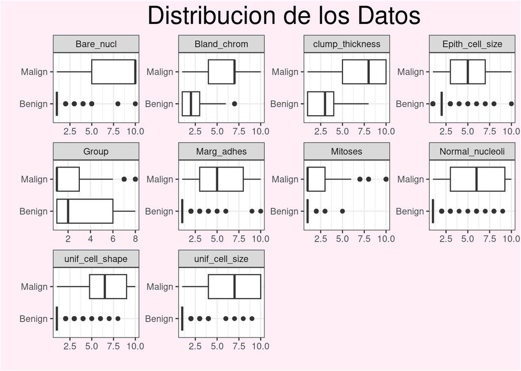

```r
distribucion_datos
```

Una vez que ya tenemos los datos limpios y hemos analizado su distribución podemos empezar a realizar el modelo. Primero vamos a hacer una cross-validation. Barajamos las filas del dataframe y lo dividimos en tres partes. Luego hacemos las distintas combinaciones de esas tres partes para los distintos grupos de entreno y testeo para el cross-validation

```r
## Barajamos las filas del dataframe
train_complete<- train_complete[sample(1:length(row_number(train_complete))),]

tercio <- round(length(row_number(train_complete))/3)

##Dividimos el dataframe el tres partes con el mismo numero de filas
train_group1 <- train_complete[1:tercio,]
train_group2 <- train_complete[(tercio+1):(tercio*2),]
train_group3 <- train_complete[((tercio*2)+1):length(row_number(train_complete)),]

#Hacemos los distintos grupos para el cross validation
train_1=rbind(train_group1,train_group2)
test_1=train_group3

train_2=rbind(train_group1,train_group3)
test_2=train_group2

train_3=rbind(train_group3,train_group2)
test_3=train_group1
```

Hacemos una función a la que introducimos un dataframe, una variable que queremos predecir y un p-value de threshold y nos haga el stepwise down hasta que nos quedemos únicamente con las variables significativas.

```r
#El pvalue threshold por defecto es 0.05 pero se puede cambiar
stepwise_down=function(df,prediccion,p_value_threshold=0.05){
  i=1
  #Esta parte crea la formula inicial que se usara en el glm
  formula=paste0(prediccion,"~")
  resto_variables <-  colnames(df)[!(colnames(df)==prediccion)]
  for (name in 1:(length(resto_variables))){
    if (name==1){
      formula=paste0(formula,resto_variables[name])
    }else{
      formula=paste(formula,resto_variables[name],sep="+")
    }

  }

  #Inicializamos el for donde iremos quitando creando un glm y quitando la variable menos significativa en cada bucle
  for (step in 1:100){
    #Hacemos el glm
    modelo=glm(formula,df,family=(binomial(link="logit")))
    resumen=summary(modelo)
    lista=(2:length(rownames(resumen$coefficients)))
    #Quitamos el intercept del dataframe.
    resumen=resumen$coefficients[lista,]
    #Aislamos la variable con mayor p_value
    menos_influyente=rownames(resumen)[resumen[,4]==max(resumen[,4])]
    #Aislamos la primera variable de la formula
    primero_en_formula=unlist(str_split(str_remove(formula,paste0(prediccion,"~")),pattern = "\\+"))[1]
    #Si el p_value de la variable menos influyente es menor del threshold establecido se sale del for y se termina la funcion
    if(resumen[,4][resumen[,4]==max(resumen[,4])]<p_value_threshold){

      break
    }
    #Si la menos influyente es la primera la quitamos de la formula
    if (menos_influyente==primero_en_formula){
      formula=str_remove(formula,paste0(menos_influyente,"\\+"))
    #Si no es la primera la quitamos de una manera ligeramente distinta
    }else{
      formula=str_remove(formula,paste0("\\+",menos_influyente))
    }


  }
  #Devolvemos el modelo glm
  return(modelo)
}
```

También creamos una función ROC que nos calcule la sensibilidad y el False Positive Rate para distintos cutoff valúes para clasificar un tumor como “Malign”. Esto nos ayudara a seleccionar el mejor cut-off valué para el modelo y también nos dará una idea de lo eficaz que es el modelo a la hora de diagnosticar.

```r
ROC=function(df,col_test,col_predic,variable_positive,variable_negative){

  #Creamos vectores que almacenen la sensibilidad el FPR y el cutoff value en cada iteration del for
  sens=vector()
  FPR=vector()
  thresh=vector()
  #Cremos un for donde el cutoff value vaya incrementando de 0 a 1 en pasos de 0.01
  for(threshold in seq(0,1,0.01)){
    dataframe=df
    #Transformamos la columna de de predicciones que tiene probabilidades de 0 a 1 en "Benign" y "Malign" en base a si esa probabilidad supera el cutoff value
    dataframe[,col_predic]=ifelse(dataframe[,col_predic]<=threshold,0,1)
    dataframe[,col_predic]=as.factor( dataframe[,col_predic])
    levels( dataframe[,col_predic]) <- c(variable_negative,variable_positive)
    #Sacamos las estadisticas de ese dataframe
    esta=estadisticas(dataframe,col_test,col_predic,variable_positive,variable_negative,show=FALSE)
    #Metemos las estadisticas y el cutoff en los vectores
    thresh=append(thresh,threshold)
    sens=append(sens,esta[1,])
    FPR=append(FPR,esta[5,])

  }
  #Combinamos los vectores en un data frame y lo devolvemos
  resultados=as.data.frame(cbind(thresh,sens,FPR))
  return(resultados)
}
```

Hacemos el stepwise de los tres grupos en los que hemos dividido el train dataset y los testeamos. Si el modelo funciona bien y no hace overfiting de los datos los resultados de las predicciones de los distintos sets de cross validation deberían ser similares. Vemos que las estadísticas son muy parecidas por lo que el modelo no hace overfitting y es adecuado.

```r
#Sacamos el modelo de cada grupo de entrenamiento
modelo1=stepwise_down(train_1,"class")
modelo2=stepwise_down(train_2,"class")
modelo3=stepwise_down(train_3,"class")


#Hacemos las predicciones y las redondeamos a 0 o 1 y les asignamos el nivel.
prediccion1=as.factor(round(predict(modelo1,test_1,type="response")))
levels(prediccion1) <- c("Benign","Malign")
prediccion2=as.factor(round(predict(modelo2,test_2,type="response")))
levels(prediccion2) <- c("Benign","Malign")
prediccion3=as.factor(round(predict(modelo3,test_3,type="response")))
levels(prediccion3) <- c("Benign","Malign")

#Sacamos las estadisticas
comparacion1 <- cbind(test_1,prediccion1)
estadisticas_cv1 <- estadisticas(comparacion1,"class","prediccion1","Malign","Benign",show=FALSE)

comparacion2<- cbind(test_2,prediccion2)
estadisticas_cv2 <- estadisticas(comparacion2,"class","prediccion2","Malign","Benign",show=FALSE)


comparacion3 <- cbind(test_3,prediccion3)
estadisticas_cv3 <- estadisticas(comparacion3,"class","prediccion3","Malign","Benign",show=FALSE)

print(cbind(estadisticas_cv1,estadisticas_cv2,estadisticas_cv3))
```

```
##                 %     %     %
## sensitivity 90.20 95.65 90.28
## specificity 96.27 97.41 98.23
## PPV         90.20 95.65 97.01
## NPV         96.27 97.41 94.07
## FPR          3.73  2.59  1.77
## FNR          9.80  4.35  9.72
## Accuracy    94.59 96.76 95.14
```

Ahora hacemos el modelo con todo el training dataset y hacemos la prediccion del test dataset.

```r
#Hacemos el stepwise y obtenemos el modelo
modelo_final=stepwise_down(train_complete,"class",p_value_threshold = 0.05)
summary(modelo_final)
```

```
##
## Call:
## glm(formula = formula, family = (binomial(link = "logit")), data = df)
##
## Coefficients:
##                 Estimate Std. Error z value Pr(>|z|)
## (Intercept)     -9.87503    1.14374  -8.634  < 2e-16 ***
## clump_thickness  0.76052    0.15006   5.068 4.02e-07 ***
## Marg_adhes       0.31585    0.11623   2.718 0.006577 **
## Bare_nucl        0.41986    0.09105   4.611 4.00e-06 ***
## Bland_chrom      0.54724    0.15167   3.608 0.000308 ***
## Normal_nucleoli  0.31157    0.09825   3.171 0.001518 **
## ---
## Signif. codes:  0 '***' 0.001 '**' 0.01 '*' 0.05 '.' 0.1 ' ' 1
##
## (Dispersion parameter for binomial family taken to be 1)
##
##     Null deviance: 715.84  on 554  degrees of freedom
## Residual deviance: 100.84  on 549  degrees of freedom
## AIC: 112.84
##
## Number of Fisher Scoring iterations: 8
```

```r
#Predecimos si el tumor es maligno o no con los datos del test dataset
prediccion_final=predict(modelo_final,test_complete,type="response")
levels(prediccion_final) <- c("Benign","Malign")
#Esas predicciones las juntamos con el dataframe del test dataset
comparacion_final <- cbind(test_complete,prediccion_final)

#Con el objetivo de plotear las probabilidades que hemos predecido ordenamos el dataframe en funcion de esa columna
comparacion_final <- comparacion_final[order(comparacion_final$prediccion_final),]
comparacion_final <- cbind(comparacion_final,seq(1,length(rownames(comparacion_final))))
colnames(comparacion_final)[14] <- "indice"
#Ploteamos la columna de las predicciones
DIST=ggplot(comparacion_final,aes(x=indice,y=prediccion_final))+geom_point()+ylab("Valores")+xlab("Datos de predicción")+theme_bw()+theme(axis.title.x = element_text(size = 18),axis.title.y = element_text(size = 18),axis.text.x =element_text(size = 14),axis.text.y =element_text(size = 14),plot.background = element_rect(rgb(255, 238, 245 , maxColorValue = 255)))
png(filename = "../graphs/prediccion_distribucion.png",units = "cm",height = 15,width = 20,res = 500)
DIST
dev.off()
```

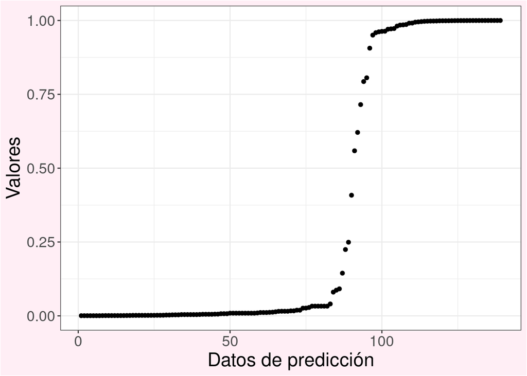

```r
DIST
```

Vamos a hacer el ROC para hacernos una idea de lo bien que funciona el modelo y elegir un cutoff value adecuado para obtener una sensibilidad del 100%, ya que en caso de enfermedades tan graves es mejor diagnosticar erróneamente a alguien pero detectar el 100% de los casos.

```r
#Hacemos el ROC y lo ploteamos
roc=ROC(comparacion_final,"class","prediccion_final","Malign","Benign")
#Ordenamos el dataframe en funcion de la sensibilidad
roc=roc[order(roc$sens),]
#Ploteamos la sensibilidad contra el FPR
ROC=ggplot(roc,aes(x=FPR,y=sens))+geom_point()+geom_line()+ylab("Sensibilidad")+
  geom_text(aes(label = "Cutoff:0.24"), x = 5, y = 90, hjust = -0.2, vjust = 0.5,size=8)+ggtitle("ROC")+
  geom_curve(aes(x = 5, y = 90, xend = 4.4, yend = 100),
             curvature = -0.2,
             arrow = arrow(length = unit(0.2, "inches")))+
  theme_bw()+
  theme(axis.title.x = element_text(size = 18),axis.title.y = element_text(size = 18),axis.text.x =element_text(size = 14),axis.text.y =element_text(size = 14),plot.title = element_text(hjust = 0.5,size=20),plot.background = element_rect(rgb(255, 238, 245 , maxColorValue = 255)))
png(filename = "../graphs/ROC.png",units = "cm",height = 15,width = 20,res = 500)
ROC
dev.off()
```

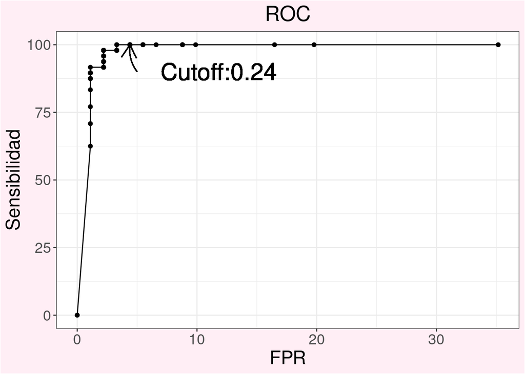

```r
ROC
```

```r
#Vemos que el cutoff mas alto que tiene un 100% de sensibilidad es 0.24
cutoff=max(roc[roc$sens==100,][,1])
```

Ahora con ese cutoff value redondeamos las probabilidades de la prediccion y calculamos las estadisticas de nuestro modelo.

```r
#Sacamos las estadisticas del modelo con el cutoff value de 0.24
comparacion_final[,"prediccion_final"]=as.factor(ifelse(comparacion_final[,"prediccion_final"]<=cutoff,0,1))
levels(comparacion_final[,"prediccion_final"])=c("Benign","Malign")
estats=estadisticas(comparacion_final,"class","prediccion_final","Malign","Benign",show=FALSE)
print(estats)
```

```
##                  %
## sensitivity 100.00
## specificity  96.70
## PPV          94.12
## NPV         100.00
## FPR           3.30
## FNR           0.00
## Accuracy     97.84
```